# TidyR_homework_mcewen

Gavin McEwen

2026-04-20

## TidyR Homework

In this assignment, you will be asked to select a dataset of your choice, identify any ‘untidy’ characteristics, make it tidy, and do some exploratory analysis.

## Question 1 (1 point)

Select a dataset from https://github.com/rfordatascience/tidytuesday/tree/main/data and import it into RStudio.

If your dataset references a paper, like the one we did in class, you can download it from its data repository. If it is only found on the tidy tuesday github, you may need to use one of these functions: tidytuesdayR::tt_load readr::read_csv

Show me the first *10 rows* of your data (1 point).

```r
package_list <- c("dplyr", "readr", "tidyverse", "tidyr", "lubridate", "dedupewider")

for (pckg in package_list) { #Installs packages in package_list
  if (!requireNamespace(pckg, quietly = TRUE)) {
    install.packages(pckg, dependencies = TRUE)
  }
  library(pckg, character.only = TRUE)
}
dls_protein_corona_size = read_csv("20250502.csv") #Reads in a raw csv file
head(dls_protein_corona_size, 10) #Outputs the first 10 rows of data
```

| Type | Sample Name | S/W Version | Serial Number | Measurement Date and Time | Z-Average (d.nm) | PdI | Sizes[1] (d.nm) | Sizes[2] (d.nm) | Sizes[3] (d.nm) | Sizes[4] (d.nm) | Sizes[5] (d.nm) | Sizes[6] (d.nm) | Sizes[7] (d.nm) | Sizes[8] (d.nm) | Sizes[9] (d.nm) | Sizes[10] (d.nm) | Sizes[11] (d.nm) | Sizes[12] (d.nm) | Sizes[13] (d.nm) | Sizes[14] (d.nm) | Sizes[15] (d.nm) | Sizes[16] (d.nm) | Sizes[17] (d.nm) | Sizes[18] (d.nm) | Sizes[19] (d.nm) | Sizes[20] (d.nm) | Sizes[21] (d.nm) | Sizes[22] (d.nm) | Sizes[23] (d.nm) | … |
| --- | --- | --- | --- | --- | --- | --- | --- | --- | --- | --- | --- | --- | --- | --- | --- | --- | --- | --- | --- | --- | --- | --- | --- | --- | --- | --- | --- | --- | --- | --- |
| Size | SeNP_only_15min 1 | 8.02 | MAL1086566 | Friday, May 2, 2025 11:22:35 AM | 49.25 | 0.051 | 0.4 | 0.4632 | 0.5365 | 0.6213 | 0.7195 | 0.8332 | 0.9649 | 1.117 | 1.294 | 1.499 | 1.736 | 2.01 | 2.328 | 2.696 | 3.122 | 3.615 | 4.187 | 4.849 | 5.615 | 6.503 | 7.531 | 8.721 | 10.1 | … |
| Size | SeNP_only_15min 2 | 8.02 | MAL1086566 | Friday, May 2, 2025 11:25:08 AM | 47.61 | 0.032 | 0.4 | 0.4632 | 0.5365 | 0.6213 | 0.7195 | 0.8332 | 0.9649 | 1.117 | 1.294 | 1.499 | 1.736 | 2.01 | 2.328 | 2.696 | 3.122 | 3.615 | 4.187 | 4.849 | 5.615 | 6.503 | 7.531 | 8.721 | 10.1 | … |
| Type | Sample Name | S/W Version | Serial Number | Measurement Date and Time | Z-Average (d.nm) | PdI | Sizes[1] (d.nm) | Sizes[2] (d.nm) | Sizes[3] (d.nm) | Sizes[4] (d.nm) | Sizes[5] (d.nm) | Sizes[6] (d.nm) | Sizes[7] (d.nm) | Sizes[8] (d.nm) | Sizes[9] (d.nm) | Sizes[10] (d.nm) | Sizes[11] (d.nm) | Sizes[12] (d.nm) | Sizes[13] (d.nm) | Sizes[14] (d.nm) | Sizes[15] (d.nm) | Sizes[16] (d.nm) | Sizes[17] (d.nm) | Sizes[18] (d.nm) | Sizes[19] (d.nm) | Sizes[20] (d.nm) | Sizes[21] (d.nm) | Sizes[22] (d.nm) | Sizes[23] (d.nm) | … |
| Size | extract_only_15min 1 | 8.02 | MAL1086566 | Friday, May 2, 2025 11:30:23 AM | 42.02 | 0.438 | 0.4 | 0.4632 | 0.5365 | 0.6213 | 0.7195 | 0.8332 | 0.9649 | 1.117 | 1.294 | 1.499 | 1.736 | 2.01 | 2.328 | 2.696 | 3.122 | 3.615 | 4.187 | 4.849 | 5.615 | 6.503 | 7.531 | 8.721 | 10.1 | … |
| Size | extract_only_15min 2 | 8.02 | MAL1086566 | Friday, May 2, 2025 11:32:26 AM | 41.89 | 0.455 | 0.4 | 0.4632 | 0.5365 | 0.6213 | 0.7195 | 0.8332 | 0.9649 | 1.117 | 1.294 | 1.499 | 1.736 | 2.01 | 2.328 | 2.696 | 3.122 | 3.615 | 4.187 | 4.849 | 5.615 | 6.503 | 7.531 | 8.721 | 10.1 | … |
| Type | Sample Name | S/W Version | Serial Number | Measurement Date and Time | Z-Average (d.nm) | PdI | Sizes[1] (d.nm) | Sizes[2] (d.nm) | Sizes[3] (d.nm) | Sizes[4] (d.nm) | Sizes[5] (d.nm) | Sizes[6] (d.nm) | Sizes[7] (d.nm) | Sizes[8] (d.nm) | Sizes[9] (d.nm) | Sizes[10] (d.nm) | Sizes[11] (d.nm) | Sizes[12] (d.nm) | Sizes[13] (d.nm) | Sizes[14] (d.nm) | Sizes[15] (d.nm) | Sizes[16] (d.nm) | Sizes[17] (d.nm) | Sizes[18] (d.nm) | Sizes[19] (d.nm) | Sizes[20] (d.nm) | Sizes[21] (d.nm) | Sizes[22] (d.nm) | Sizes[23] (d.nm) | … |
| Size | Se_0.5mg/mL_15min 1 | 8.02 | MAL1086566 | Friday, May 2, 2025 11:37:43 AM | 46.95 | 0.055 | 0.4 | 0.4632 | 0.5365 | 0.6213 | 0.7195 | 0.8332 | 0.9649 | 1.117 | 1.294 | 1.499 | 1.736 | 2.01 | 2.328 | 2.696 | 3.122 | 3.615 | 4.187 | 4.849 | 5.615 | 6.503 | 7.531 | 8.721 | 10.1 | … |
| Size | Se_0.5mg/mL_15min 2 | 8.02 | MAL1086566 | Friday, May 2, 2025 11:40:06 AM | 46.43 | 0.067 | 0.4 | 0.4632 | 0.5365 | 0.6213 | 0.7195 | 0.8332 | 0.9649 | 1.117 | 1.294 | 1.499 | 1.736 | 2.01 | 2.328 | 2.696 | 3.122 | 3.615 | 4.187 | 4.849 | 5.615 | 6.503 | 7.531 | 8.721 | 10.1 | … |
| Type | Sample Name | S/W Version | Serial Number | Measurement Date and Time | Z-Average (d.nm) | PdI | Sizes[1] (d.nm) | Sizes[2] (d.nm) | Sizes[3] (d.nm) | Sizes[4] (d.nm) | Sizes[5] (d.nm) | Sizes[6] (d.nm) | Sizes[7] (d.nm) | Sizes[8] (d.nm) | Sizes[9] (d.nm) | Sizes[10] (d.nm) | Sizes[11] (d.nm) | Sizes[12] (d.nm) | Sizes[13] (d.nm) | Sizes[14] (d.nm) | Sizes[15] (d.nm) | Sizes[16] (d.nm) | Sizes[17] (d.nm) | Sizes[18] (d.nm) | Sizes[19] (d.nm) | Sizes[20] (d.nm) | Sizes[21] (d.nm) | Sizes[22] (d.nm) | Sizes[23] (d.nm) | … |
| Size | Se_0.2mg/mL_15min 1 | 8.02 | MAL1086566 | Friday, May 2, 2025 11:46:28 AM | 46.72 | 0.087 | 0.4 | 0.4632 | 0.5365 | 0.6213 | 0.7195 | 0.8332 | 0.9649 | 1.117 | 1.294 | 1.499 | 1.736 | 2.01 | 2.328 | 2.696 | 3.122 | 3.615 | 4.187 | 4.849 | 5.615 | 6.503 | 7.531 | 8.721 | 10.1 | … |

## Question 2 (3 points)

Identify at least 3 non-tidy characteristics of your data or things you would like to change in this dataset (1 point ea):

1. Each set of sample measurement duplicates is preceded by a header row, so that the column headers appear multiple times in each column.
2. The size values (in nm) and the intensity values corresponding to those sizes are contained in the same row. They should each be contained in different columns.
3. The NP concentration and replicate number is all contained in the sample name.
4. The “S/W Version” and “Serial Number” are useless information because they are the same for all samples.
5. The measurement date and time contains characters, but I would like to convert it to numeric.

## Question 3 (5 points)

Fix each of your issues. Use comments to show where each of your issues listed above was fixed. Use pipes to connect fixing all of your issues together!

```r
dls_protein_corona_size_cleaned = dls_protein_corona_size %>%
  filter(Type == "Size",) %>% #Removes interdigitated header rows, addresses issue 1 above
  select(-c(`S/W Version`, `Serial Number`)) %>% #Removes "S/W Version" and "Serial Number" columns, addresses issue 4 above
  mutate(
    datetime = as.POSIXct(`Measurement Date and Time`,
                          format = "%A, %B %d, %Y %I:%M:%S %p"),
    measurement_time_numeric = hour(datetime) + minute(datetime)/60 + second(datetime)/3600) %>% #Converts "Measurement Date and Time" column to numeric decimal hours, addresses issue 5 above
  select(-c(`Measurement Date and Time`)) %>% #Removes "Measurement Date and Time" column
  separate(`Sample Name`, into = c("sample_info", "replicate"), sep = " ") %>%
  mutate(
    replicate = as.integer(replicate), #Extracts replicate information and adds it to the new column "replicate"
    concentration = str_extract(`sample_info`, "(?<=_)\\d+\\.?\\d*(?=mg/mL)") #Extracts NP concentration in mg/mL and adds it to the new column "concentration", addresses issue 3 above
  )

sizes_and_intensities = dls_protein_corona_size_cleaned %>%
  select(c(`sample_info`, starts_with("Sizes"), starts_with("Intensities"))) #Creates a new dataframe specifically for intensity versus size data

colnames(sizes_and_intensities)[72:141] = sizes_and_intensities[1, 2:71] #Renames column headers of intensity data with size values from row 1, addresses issue 2 above

sizes_and_intensities_cleaned = sizes_and_intensities %>%
  select(-c(starts_with("Sizes"))) %>% #Removes repetitive size data
  pivot_longer(cols = -1, names_to = "size_nm", values_to = "intensity_percent") #Pivots table so that size values and intensities are in separate columns, addresses issue 2 above

sizes_and_intensities_cleaned$size_nm = as.numeric(sizes_and_intensities_cleaned$size_nm) #Converts "size_nm" values to numeric format
sizes_and_intensities_cleaned$intensity_percent = as.numeric(sizes_and_intensities_cleaned$intensity_percent) #Converts "intensity_percent" values to numeric format

dls_protein_corona_size_concentration = dls_protein_corona_size_cleaned %>%
  select(-c(starts_with("Intensities"), starts_with("Sizes"), starts_with("Volumes"))) %>% #Creates a new dataframe specifically for average size (and associated PDI values) versus concentration or time
  drop_na(`concentration`) %>% #Drops all rows with NA in the "concentration" column, as these are control samples
  mutate(elapsed_time = `measurement_time_numeric` - `measurement_time_numeric`[1]) #Computes the elapsed time since the first measurement

dls_protein_corona_size_concentration$`Z-Average (d.nm)` = as.numeric(dls_protein_corona_size_concentration$`Z-Average (d.nm)`) #Converts "Z-Average (d.nm)" values to numeric format
dls_protein_corona_size_concentration$PdI = as.numeric(dls_protein_corona_size_concentration$PdI) #Converts "PdI" values to numeric format
dls_protein_corona_size_concentration$concentration = as.factor(dls_protein_corona_size_concentration$concentration) #Converts "concentration" values to factors
```

## Question 4 (2 points)

List a question you would like to answer using this dataset:

How does the average hydrodynamic particle diameter change as a function of incubation time and as a function of protein concentration?

## Question 5 (5 points)

Using stats, plots, or both, answer your question. Make sure you output any stats or plots you create in this code chunk (i.e., that it shows up in the knitted document).

NOTE: you do not have to use a formal stats test if you are not familiar! Feel free to just use summary stats and/or figures to answer your question.

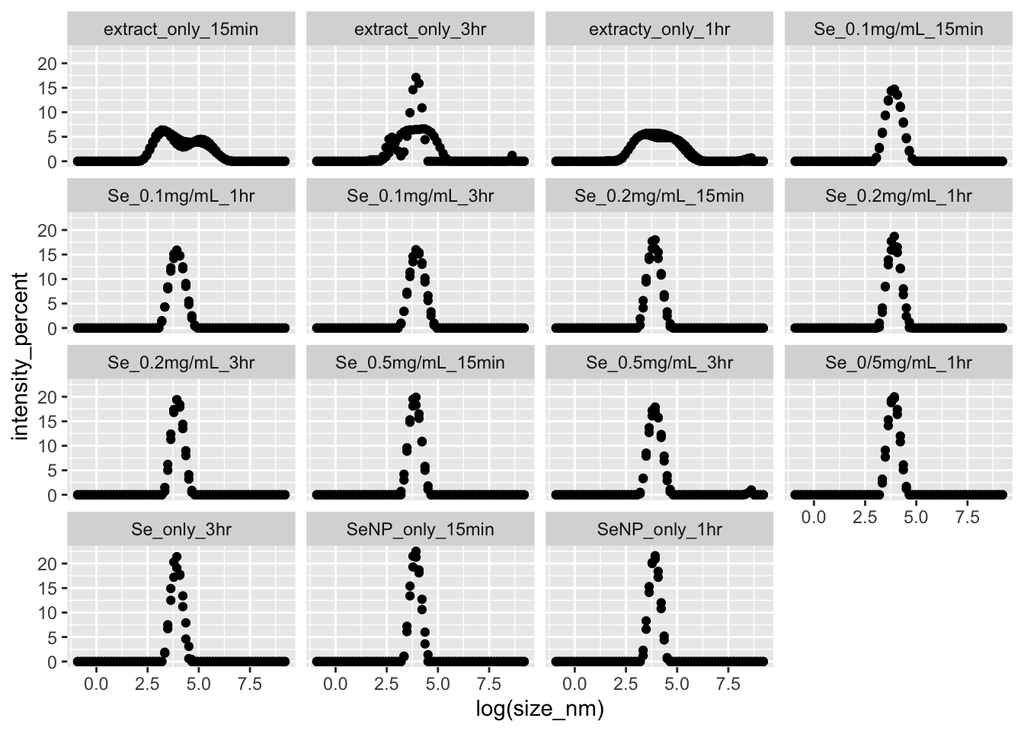

```r
sizes_and_intensities_cleaned %>%
  ggplot(aes(x=log(size_nm), y=intensity_percent)) +
  geom_point() +
  facet_wrap(~ sample_info)
```

```
## `summarise()` has regrouped the output.
## ℹ Summaries were computed grouped by sample_info and concentration.
## ℹ Output is grouped by sample_info.
## ℹ Use `summarise(.groups = "drop_last")` to silence this message.
## ℹ Use `summarise(.by = c(sample_info, concentration))` for per-operation
##   grouping (`?dplyr::dplyr_by`) instead.
```

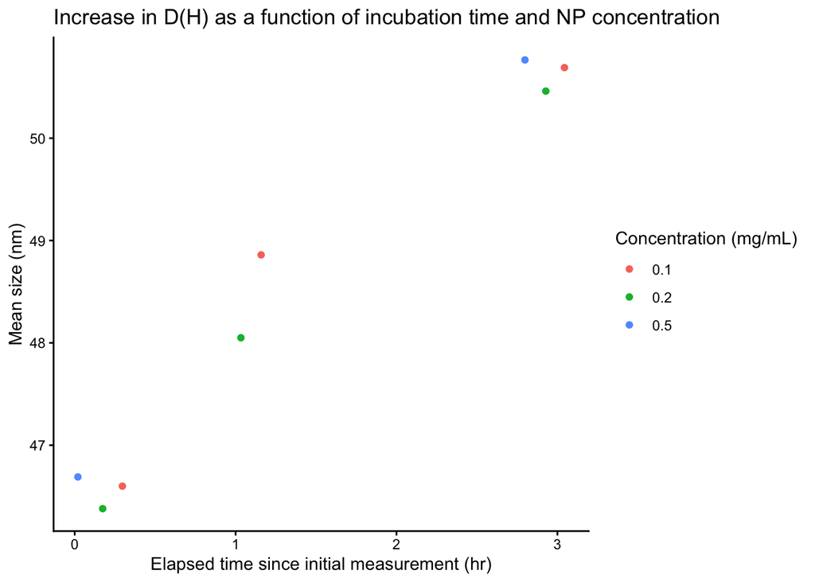

```r
dls_protein_corona_size_concentration %>%
  group_by(sample_info, concentration) %>%
  summarise(mean_size = mean(`Z-Average (d.nm)`),
            mean_time = mean(elapsed_time),
            sd_size = sd(`Z-Average (d.nm)`),
            sd_time = sd(elapsed_time),
            n = n(),
            se_size = sd_size/sqrt(n),
            se_time = sd_time/sqrt(n)) %>%
  ggplot(aes(x=mean_time, y=mean_size, color = concentration)) +
  geom_point() +
  labs(x = "Elapsed time since initial measurement (hr)",
       y = "Mean size (nm)",
       title = "Increase in D(H) as a function of incubation time and NP concentration",
       color = "Concentration (mg/mL)") +
  theme(plot.title = element_text(hjust = 0.5), plot.subtitle = element_text(hjust = 0.5)) +
  theme_classic()
```

## Question 6 (4 points)

Find two functions we haven’t introduced you to that are a part of tidyR, dplyr, or other related tidyverse packages. Provide the function name (including the package it’s from) and what it does.

1. The relocate() function from the dplyr package will change the position of columns without removing them.
2. The replace_na() function from the tidyR package will replace all NA values with a specific, known value